# Commuter Friction Survey – Descriptive Data Analysis

#### Stress level by one-way trip time

|  | One-way trip time | Low | Moderate | High | Total |
| --- | --- | --- | --- | --- | --- |
| Under 30 min | Under 30 min | 13 (29.5%) | 28 (63.6%) | 3 (6.8%) | 44 (100%) |
| 30–59 min | 30–59 min | 2 (5.7%) | 26 (74.3%) | 7 (20.0%) | 35 (100%) |
| 1 to 1½ hours | 1 to 1½ hours | 0 (0.0%) | 18 (75.0%) | 6 (25.0%) | 24 (100%) |
| 1½ to 2 hours | 1½ to 2 hours | 0 (0.0%) | 9 (39.1%) | 14 (60.9%) | 23 (100%) |
| Over 2 hours | Over 2 hours | 0 (0.0%) | 4 (66.7%) | 2 (33.3%) | 6 (100%) |
| 6 | Total | 15 (11.4%) | 85 (64.4%) | 32 (24.2%) | 132 (100%) |

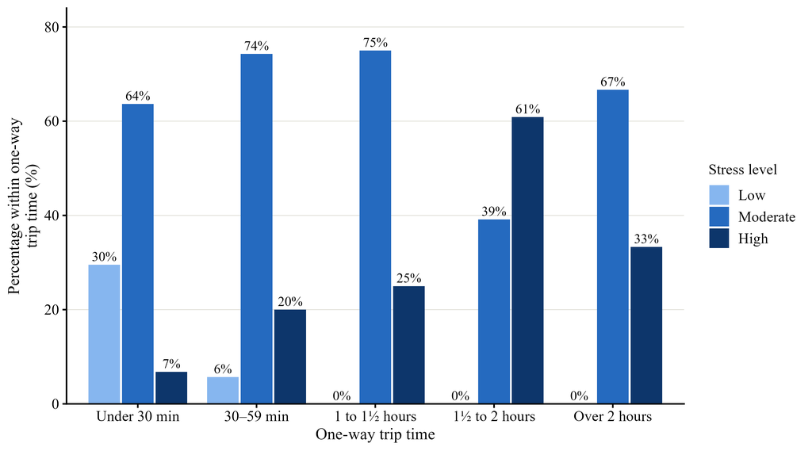

Trip time shows the clearest relationship with stress. Low stress is found mainly among students whose trips take under 30 minutes (29.5%) and disappears completely for trips of one hour or more. The share of highly stressed students rises from 6.8% (under 30 minutes) to 20.0% (30–59 minutes), 25.0% (1 to 1½ hours) and 60.9% (1½ to 2 hours). The over-2-hours group is small (n = 6), so its lower value (33.3%) should be interpreted with caution.

#### Stress level by waiting time for vehicle

|  | Waiting time for vehicle | Low | Moderate | High | Total |
| --- | --- | --- | --- | --- | --- |
| I don’t wait | I don’t wait | 9 (20.9%) | 31 (72.1%) | 3 (7.0%) | 43 (100%) |
| Under 5 min | Under 5 min | 3 (12.0%) | 18 (72.0%) | 4 (16.0%) | 25 (100%) |
| 5–15 min | 5–15 min | 3 (6.2%) | 29 (60.4%) | 16 (33.3%) | 48 (100%) |
| 15 min or more | 15 min or more | 0 (0.0%) | 7 (43.8%) | 9 (56.2%) | 16 (100%) |
| 5 | Total | 15 (11.4%) | 85 (64.4%) | 32 (24.2%) | 132 (100%) |

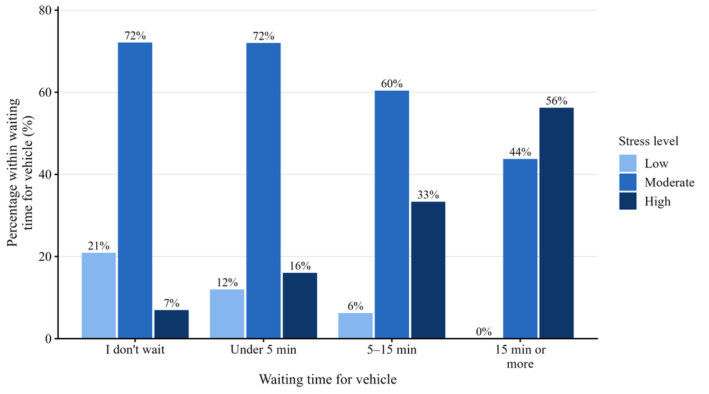

Stress increases with waiting time. Only 7.0% of students who do not wait are highly stressed, compared with 16.0% of those who wait under 5 minutes, 33.3% of those who wait 5–15 minutes and 56.2% of those who wait 15 minutes or more. Conversely, low stress falls from 20.9% to 0.0%.

#### Stress level by departure time

|  | Departure time | Low | Moderate | High | Total |
| --- | --- | --- | --- | --- | --- |
| Before 6:00 am | Before 6:00 am | 1 (6.7%) | 7 (46.7%) | 7 (46.7%) | 15 (100%) |
| 6:00–6:59 am | 6:00–6:59 am | 3 (5.9%) | 34 (66.7%) | 14 (27.5%) | 51 (100%) |
| 7:00–7:59 am | 7:00–7:59 am | 9 (17.3%) | 33 (63.5%) | 10 (19.2%) | 52 (100%) |
| 8:00 am or later | 8:00 am or later | 2 (14.3%) | 11 (78.6%) | 1 (7.1%) | 14 (100%) |
| 5 | Total | 15 (11.4%) | 85 (64.4%) | 32 (24.2%) | 132 (100%) |

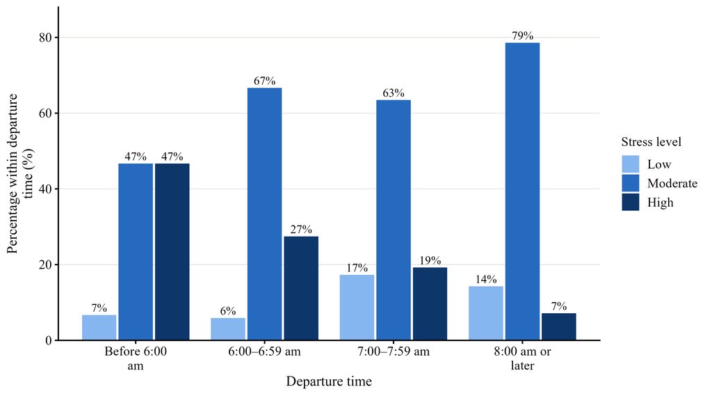

Students who leave earlier are more stressed. Nearly half of those who leave before 6:00 am (46.7%) are highly stressed, compared with 27.5% of those leaving between 6:00 and 6:59 am, 19.2% between 7:00 and 7:59 am and 7.1% at 8:00 am or later. Early departure largely reflects longer distances (see Section 1.2.2).

#### Stress level by how often students feel unsafe

|  | How often students feel unsafe | Low | Moderate | High | Total |
| --- | --- | --- | --- | --- | --- |
| Never | Never | 10 (27.8%) | 24 (66.7%) | 2 (5.6%) | 36 (100%) |
| Rarely | Rarely | 5 (10.6%) | 31 (66.0%) | 11 (23.4%) | 47 (100%) |
| Sometimes | Sometimes | 0 (0.0%) | 26 (65.0%) | 14 (35.0%) | 40 (100%) |
| Often | Often | 0 (0.0%) | 4 (44.4%) | 5 (55.6%) | 9 (100%) |
| 5 | Total | 15 (11.4%) | 85 (64.4%) | 32 (24.2%) | 132 (100%) |

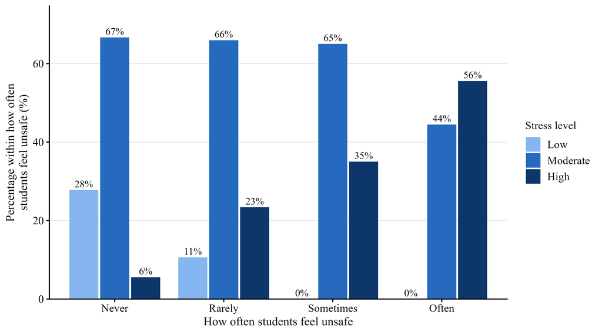

Feeling unsafe is closely linked to stress. The share of highly stressed students rises from 5.6% among those who never feel unsafe to 23.4% (rarely), 35.0% (sometimes) and 55.6% (often). Low stress is found only among students who never or rarely feel unsafe (27.8% and 10.6%).

#### Stress level by sleep quality last night

|  | Sleep quality last night | Low | Moderate | High | Total |
| --- | --- | --- | --- | --- | --- |
| Very poor | Very poor | 0 (0.0%) | 3 (60.0%) | 2 (40.0%) | 5 (100%) |
| Poor | Poor | 4 (14.8%) | 13 (48.1%) | 10 (37.0%) | 27 (100%) |
| Average | Average | 2 (3.6%) | 42 (75.0%) | 12 (21.4%) | 56 (100%) |
| Good | Good | 7 (20.0%) | 23 (65.7%) | 5 (14.3%) | 35 (100%) |
| Very good | Very good | 2 (22.2%) | 4 (44.4%) | 3 (33.3%) | 9 (100%) |
| 6 | Total | 15 (11.4%) | 85 (64.4%) | 32 (24.2%) | 132 (100%) |

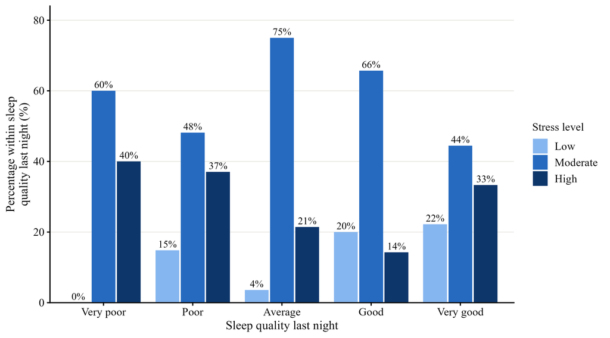

There is no clear pattern between sleep quality and stress level. High stress is somewhat more common after poor or very poor sleep (37.0% and 40.0%) than after average or good sleep (21.4% and 14.3%), but 33.3% of those who slept very well are also highly stressed. The very poor (n = 5) and very good (n = 9) groups are small, so their percentages are unstable.

#### Stress level by academic workload pressure

|  | Academic workload pressure | Low | Moderate | High | Total |
| --- | --- | --- | --- | --- | --- |
| Low | Low | 1 (7.1%) | 8 (57.1%) | 5 (35.7%) | 14 (100%) |
| Moderate | Moderate | 6 (9.4%) | 47 (73.4%) | 11 (17.2%) | 64 (100%) |
| High | High | 4 (11.1%) | 20 (55.6%) | 12 (33.3%) | 36 (100%) |
| Very high | Very high | 4 (22.2%) | 10 (55.6%) | 4 (22.2%) | 18 (100%) |
| 5 | Total | 15 (11.4%) | 85 (64.4%) | 32 (24.2%) | 132 (100%) |

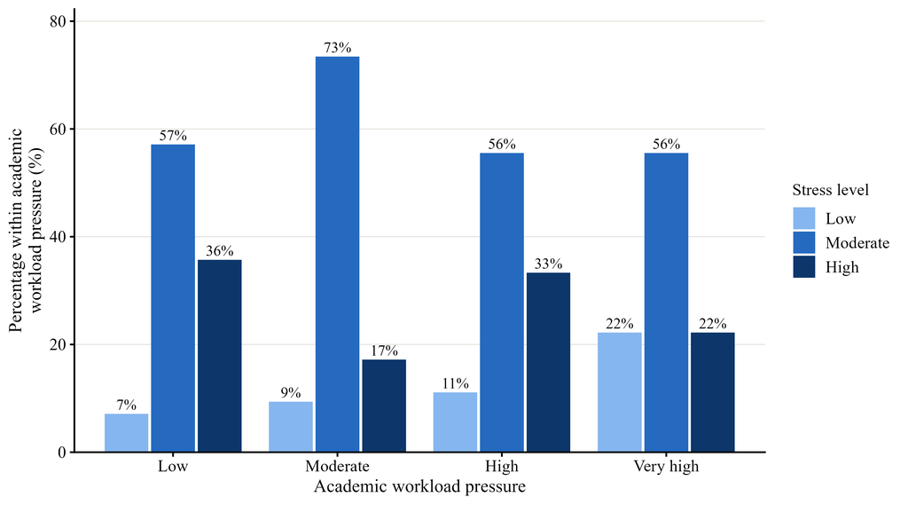

Academic workload pressure does not show a consistent relationship with commute stress. The share of highly stressed students is 35.7% in the low workload group, 17.2% for moderate, 33.3% for high and 22.2% for very high, with no steady upward or downward trend. Commute stress therefore appears to be largely independent of academic workload.

#### Stress level by crowding on bus/train

|  | Crowding on bus/train | Low | Moderate | High | Total |
| --- | --- | --- | --- | --- | --- |
| Not/slightly crowded | Not/slightly crowded | 1 (5.0%) | 17 (85.0%) | 2 (10.0%) | 20 (100%) |
| Moderately crowded | Moderately crowded | 0 (0.0%) | 17 (70.8%) | 7 (29.2%) | 24 (100%) |
| Very crowded | Very crowded | 0 (0.0%) | 14 (46.7%) | 16 (53.3%) | 30 (100%) |
| Extremely crowded | Extremely crowded | 0 (0.0%) | 3 (60.0%) | 2 (40.0%) | 5 (100%) |
| 5 | Total | 1 (1.3%) | 51 (64.6%) | 27 (34.2%) | 79 (100%) |

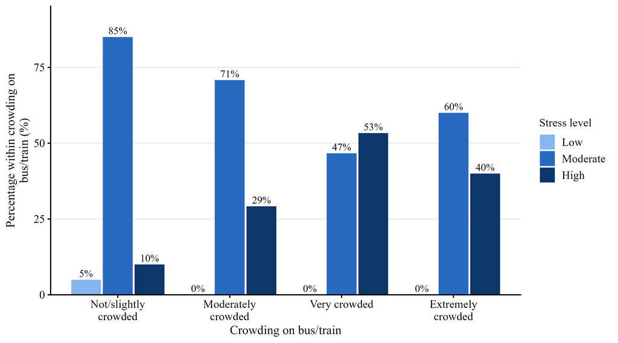

Among bus and train users, stress increases with crowding. Only 10.0% of those in not or slightly crowded vehicles are highly stressed, compared with 29.2% in moderately crowded and 53.3% in very crowded vehicles. The extremely crowded group (40.0% high stress) contains only 5 students, so this value is less reliable.

#### Stress level by weather made commute harder

|  | Weather made commute harder | Low | Moderate | High | Total |
| --- | --- | --- | --- | --- | --- |
| Not at all | Not at all | 3 (15.8%) | 14 (73.7%) | 2 (10.5%) | 19 (100%) |
| Slightly | Slightly | 4 (12.1%) | 24 (72.7%) | 5 (15.2%) | 33 (100%) |
| Moderately | Moderately | 4 (10.3%) | 25 (64.1%) | 10 (25.6%) | 39 (100%) |
| Very much | Very much | 0 (0.0%) | 16 (61.5%) | 10 (38.5%) | 26 (100%) |
| Extremely | Extremely | 4 (26.7%) | 6 (40.0%) | 5 (33.3%) | 15 (100%) |
| 6 | Total | 15 (11.4%) | 85 (64.4%) | 32 (24.2%) | 132 (100%) |

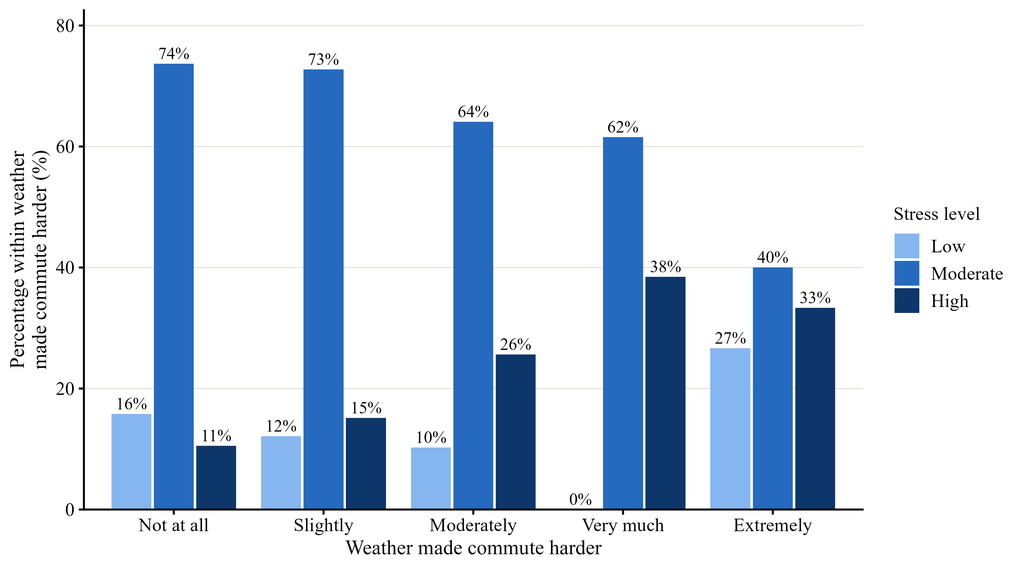

Stress tends to be higher when the weather makes the commute harder. The share of highly stressed students increases from 10.5% (not at all) and 15.2% (slightly) to 25.6% (moderately) and 38.5% (very much). In the ‘extremely’ group, both high stress (33.3%) and low stress (26.7%) are relatively common, so the pattern is less clear at the top of the scale.

### 1.2.2 Distance compared with other variables

#### Main transport mode by one-way distance to university

|  | One-way distance to university | Bus | Private vehicle | Walk or bicycle | Three-wheeler / taxi | Train | Total |
| --- | --- | --- | --- | --- | --- | --- | --- |
| Less than 5 km | Less than 5 km | 9 (25.0%) | 4 (11.1%) | 18 (50.0%) | 5 (13.9%) | 0 (0.0%) | 36 (100%) |
| 5–14 km | 5–14 km | 26 (66.7%) | 12 (30.8%) | 0 (0.0%) | 1 (2.6%) | 0 (0.0%) | 39 (100%) |
| 15–29 km | 15–29 km | 29 (65.9%) | 11 (25.0%) | 0 (0.0%) | 1 (2.3%) | 3 (6.8%) | 44 (100%) |
| 30 km or more | 30 km or more | 9 (69.2%) | 0 (0.0%) | 0 (0.0%) | 1 (7.7%) | 3 (23.1%) | 13 (100%) |
| 5 | Total | 73 (55.3%) | 27 (20.5%) | 18 (13.6%) | 8 (6.1%) | 6 (4.5%) | 132 (100%) |

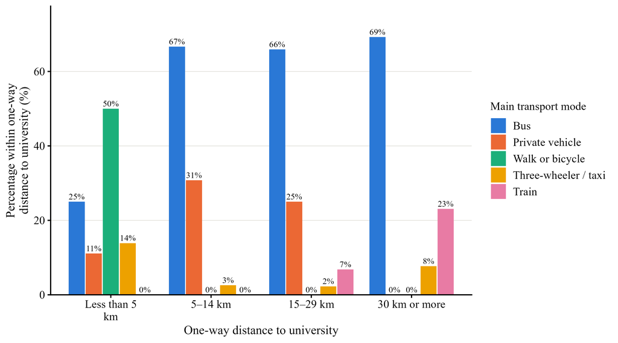

The main mode changes with distance. Half of the students living less than 5 km away walk or cycle (50.0%), but no student living further away does. For distances of 5 km or more, the bus is the dominant mode (65.9%–69.2%), and private vehicles are used by 25.0%–30.8% of students up to 29 km. The train is used only for longer trips, by 23.1% of students travelling 30 km or more.

#### Number of vehicle changes by one-way distance to university

|  | One-way distance to university | No change | 1 change | 2 changes | 3 or more changes | Total |
| --- | --- | --- | --- | --- | --- | --- |
| Less than 5 km | Less than 5 km | 28 (77.8%) | 7 (19.4%) | 1 (2.8%) | 0 (0.0%) | 36 (100%) |
| 5–14 km | 5–14 km | 18 (46.2%) | 14 (35.9%) | 5 (12.8%) | 2 (5.1%) | 39 (100%) |
| 15–29 km | 15–29 km | 15 (34.1%) | 11 (25.0%) | 13 (29.5%) | 5 (11.4%) | 44 (100%) |
| 30 km or more | 30 km or more | 1 (7.7%) | 3 (23.1%) | 7 (53.8%) | 2 (15.4%) | 13 (100%) |
| 5 | Total | 62 (47.0%) | 35 (26.5%) | 26 (19.7%) | 9 (6.8%) | 132 (100%) |

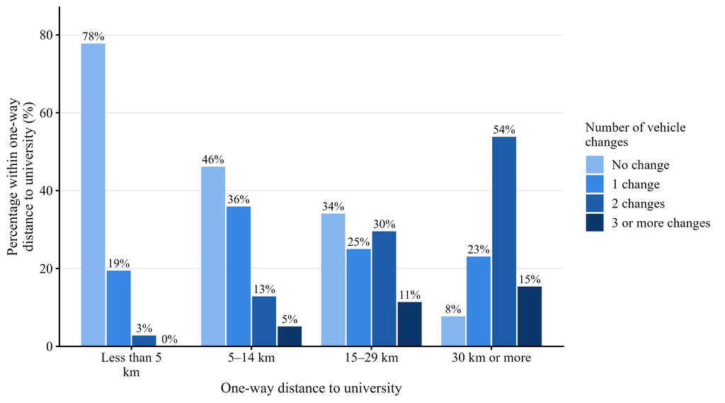

The number of vehicle changes rises sharply with distance. Most students living less than 5 km away (77.8%) do not change vehicles, but this falls to 46.2% (5–14 km), 34.1% (15–29 km) and only 7.7% (30 km or more). Among students travelling 30 km or more, 69.2% change vehicles at least twice.

#### Seat availability by one-way distance to university

|  | One-way distance to university | Get a seat | Not applicable | Stand | Total |
| --- | --- | --- | --- | --- | --- |
| Less than 5 km | Less than 5 km | 11 (30.6%) | 20 (55.6%) | 5 (13.9%) | 36 (100%) |
| 5–14 km | 5–14 km | 19 (48.7%) | 7 (17.9%) | 13 (33.3%) | 39 (100%) |
| 15–29 km | 15–29 km | 24 (54.5%) | 9 (20.5%) | 11 (25.0%) | 44 (100%) |
| 30 km or more | 30 km or more | 7 (53.8%) | 2 (15.4%) | 4 (30.8%) | 13 (100%) |
| 5 | Total | 61 (46.2%) | 38 (28.8%) | 33 (25.0%) | 132 (100%) |

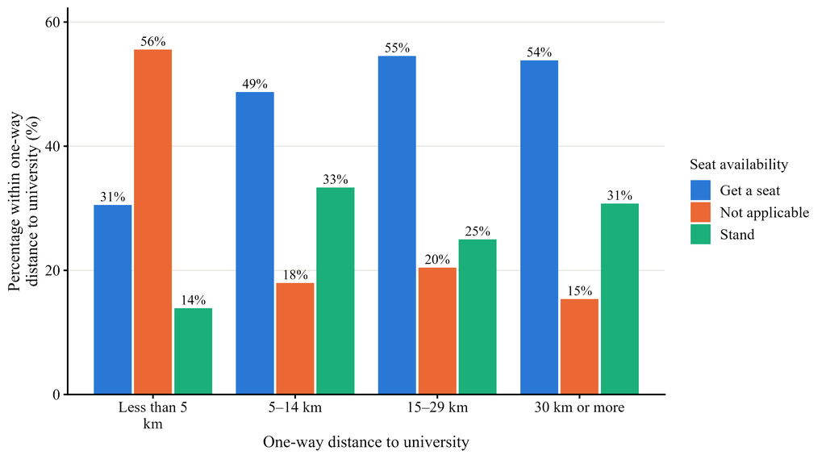

Students living close to the university are most often in the ‘not applicable’ group (55.6%), as many of them walk or cycle. For distances of 5 km or more, between 48.7% and 54.5% usually get a seat, while 25.0%–33.3% usually stand. The share who stand does not rise steadily with distance.

#### Late arrivals (15+ minutes) by one-way distance to university

|  | One-way distance to university | Never | 1 day/week | 2+ days/week | Total |
| --- | --- | --- | --- | --- | --- |
| Less than 5 km | Less than 5 km | 15 (41.7%) | 8 (22.2%) | 13 (36.1%) | 36 (100%) |
| 5–14 km | 5–14 km | 13 (33.3%) | 13 (33.3%) | 13 (33.3%) | 39 (100%) |
| 15–29 km | 15–29 km | 13 (29.5%) | 18 (40.9%) | 13 (29.5%) | 44 (100%) |
| 30 km or more | 30 km or more | 6 (46.2%) | 6 (46.2%) | 1 (7.7%) | 13 (100%) |
| 5 | Total | 47 (35.6%) | 45 (34.1%) | 40 (30.3%) | 132 (100%) |

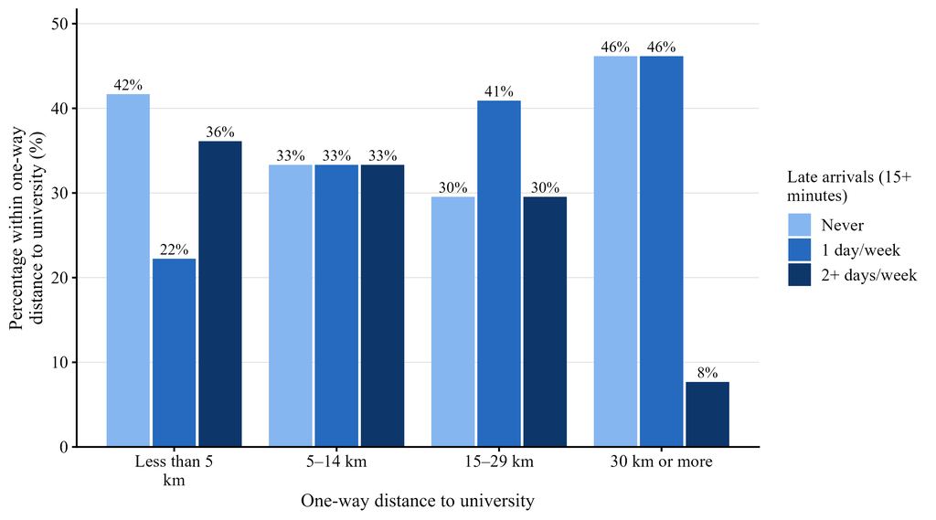

Late arrivals do not increase with distance. Students living less than 5 km away are late two or more days a week (36.1%) about as often as those living 5–14 km (33.3%) and 15–29 km (29.5%) away. Students travelling 30 km or more are the least often late (7.7% late two or more days a week), possibly because they leave much earlier.

#### One-way trip time by one-way distance to university

|  | One-way distance to university | Under 30 min | 30–59 min | 1 to 1½ hours | 1½ to 2 hours | Over 2 hours | Total |
| --- | --- | --- | --- | --- | --- | --- | --- |
| Less than 5 km | Less than 5 km | 32 (88.9%) | 3 (8.3%) | 1 (2.8%) | 0 (0.0%) | 0 (0.0%) | 36 (100%) |
| 5–14 km | 5–14 km | 11 (28.2%) | 20 (51.3%) | 6 (15.4%) | 2 (5.1%) | 0 (0.0%) | 39 (100%) |
| 15–29 km | 15–29 km | 1 (2.3%) | 12 (27.3%) | 15 (34.1%) | 14 (31.8%) | 2 (4.5%) | 44 (100%) |
| 30 km or more | 30 km or more | 0 (0.0%) | 0 (0.0%) | 2 (15.4%) | 7 (53.8%) | 4 (30.8%) | 13 (100%) |
| 5 | Total | 44 (33.3%) | 35 (26.5%) | 24 (18.2%) | 23 (17.4%) | 6 (4.5%) | 132 (100%) |

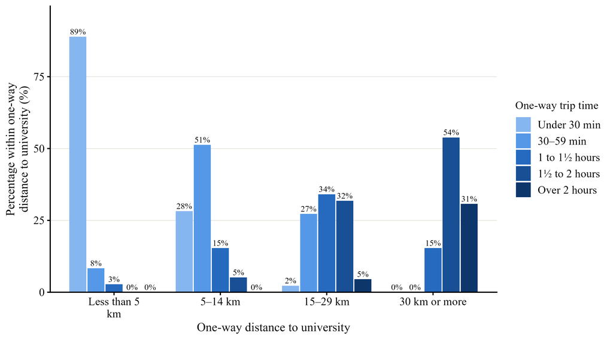

As expected, trip time increases with distance. Almost all students living less than 5 km away (88.9%) arrive in under 30 minutes, while most of those living 5–14 km away take 30–59 minutes (51.3%). At 15–29 km, 70.5% need an hour or more, and among those travelling 30 km or more, 84.6% take more than 1½ hours.

#### Share of daily budget spent on travel by one-way distance to university

|  | One-way distance to university | Nothing (0%) | Less than 10% | 10%–25% | 26%–50% | More than 50% | Total |
| --- | --- | --- | --- | --- | --- | --- | --- |
| Less than 5 km | Less than 5 km | 19 (52.8%) | 9 (25.0%) | 5 (13.9%) | 2 (5.6%) | 1 (2.8%) | 36 (100%) |
| 5–14 km | 5–14 km | 3 (7.7%) | 6 (15.4%) | 16 (41.0%) | 10 (25.6%) | 4 (10.3%) | 39 (100%) |
| 15–29 km | 15–29 km | 0 (0.0%) | 5 (11.4%) | 12 (27.3%) | 15 (34.1%) | 12 (27.3%) | 44 (100%) |
| 30 km or more | 30 km or more | 0 (0.0%) | 0 (0.0%) | 3 (23.1%) | 3 (23.1%) | 7 (53.8%) | 13 (100%) |
| 5 | Total | 22 (16.7%) | 20 (15.2%) | 36 (27.3%) | 30 (22.7%) | 24 (18.2%) | 132 (100%) |

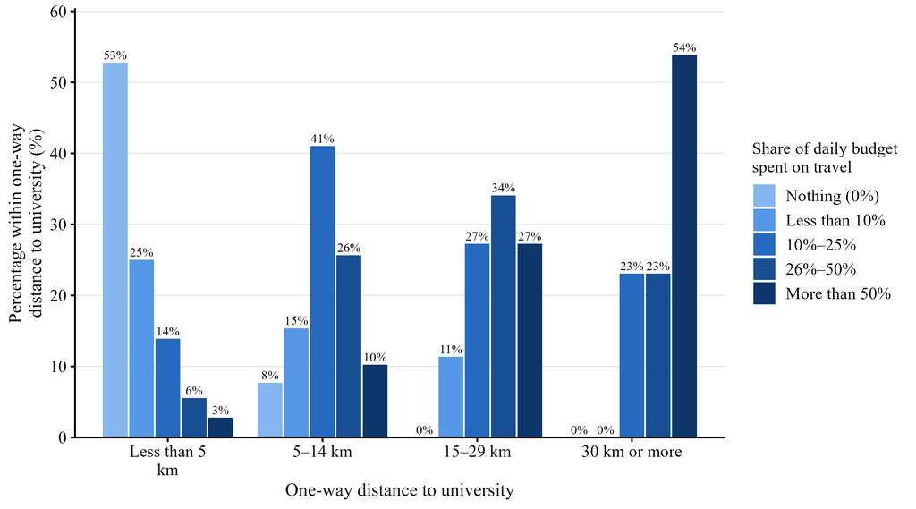

The share of the daily budget spent on travel rises with distance. More than half of the students living less than 5 km away (52.8%) spend nothing on travel, whereas more than half of those travelling 30 km or more (53.8%) spend over 50% of their daily budget. Among students living 15–29 km away, 61.4% spend more than a quarter of their budget on travel.

#### Departure time by one-way distance to university

|  | One-way distance to university | Before 6:00 am | 6:00–6:59 am | 7:00–7:59 am | 8:00 am or later | Total |
| --- | --- | --- | --- | --- | --- | --- |
| Less than 5 km | Less than 5 km | 0 (0.0%) | 3 (8.3%) | 26 (72.2%) | 7 (19.4%) | 36 (100%) |
| 5–14 km | 5–14 km | 1 (2.6%) | 13 (33.3%) | 19 (48.7%) | 6 (15.4%) | 39 (100%) |
| 15–29 km | 15–29 km | 7 (15.9%) | 29 (65.9%) | 7 (15.9%) | 1 (2.3%) | 44 (100%) |
| 30 km or more | 30 km or more | 7 (53.8%) | 6 (46.2%) | 0 (0.0%) | 0 (0.0%) | 13 (100%) |
| 5 | Total | 15 (11.4%) | 51 (38.6%) | 52 (39.4%) | 14 (10.6%) | 132 (100%) |

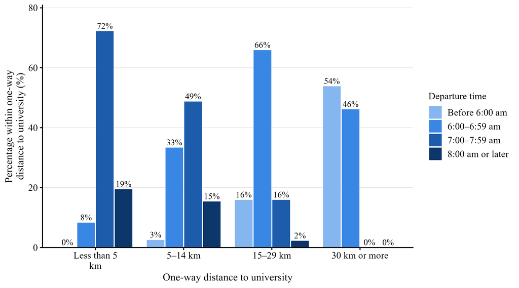

Students who live further away leave home earlier. Most students within 5 km leave between 7:00 and 7:59 am (72.2%), while most of those living 15–29 km away leave between 6:00 and 6:59 am (65.9%). More than half of those travelling 30 km or more (53.8%) leave before 6:00 am.

#### Crowding on bus/train by one-way distance to university

|  | One-way distance to university | Not/slightly crowded | Moderately crowded | Very crowded | Extremely crowded | Total |
| --- | --- | --- | --- | --- | --- | --- |
| Less than 5 km | Less than 5 km | 4 (44.4%) | 2 (22.2%) | 1 (11.1%) | 2 (22.2%) | 9 (100%) |
| 5–14 km | 5–14 km | 7 (26.9%) | 10 (38.5%) | 9 (34.6%) | 0 (0.0%) | 26 (100%) |
| 15–29 km | 15–29 km | 7 (21.9%) | 9 (28.1%) | 13 (40.6%) | 3 (9.4%) | 32 (100%) |
| 30 km or more | 30 km or more | 2 (16.7%) | 3 (25.0%) | 7 (58.3%) | 0 (0.0%) | 12 (100%) |
| 5 | Total | 20 (25.3%) | 24 (30.4%) | 30 (38.0%) | 5 (6.3%) | 79 (100%) |

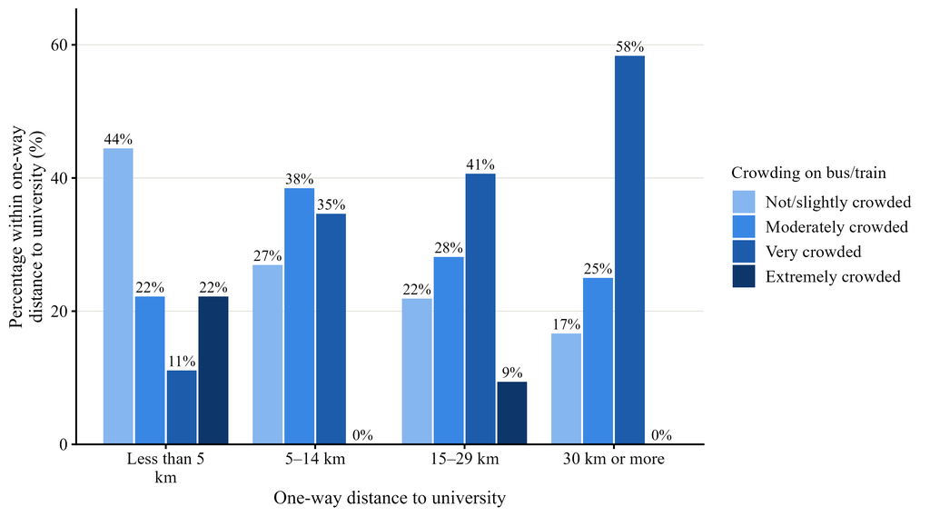

Among the 79 bus and train users, crowding tends to increase with distance. The share travelling in very crowded vehicles rises from 11.1% (less than 5 km) to 34.6% (5–14 km), 40.6% (15–29 km) and 58.3% (30 km or more). Only 9 bus or train users live within 5 km, so the percentages for that group should be read with caution.

#### Weather made commute harder by one-way distance to university

|  | One-way distance to university | Not at all | Slightly | Moderately | Very much | Extremely | Total |
| --- | --- | --- | --- | --- | --- | --- | --- |
| Less than 5 km | Less than 5 km | 8 (22.2%) | 10 (27.8%) | 9 (25.0%) | 1 (2.8%) | 8 (22.2%) | 36 (100%) |
| 5–14 km | 5–14 km | 5 (12.8%) | 9 (23.1%) | 12 (30.8%) | 10 (25.6%) | 3 (7.7%) | 39 (100%) |
| 15–29 km | 15–29 km | 5 (11.4%) | 12 (27.3%) | 13 (29.5%) | 12 (27.3%) | 2 (4.5%) | 44 (100%) |
| 30 km or more | 30 km or more | 1 (7.7%) | 2 (15.4%) | 5 (38.5%) | 3 (23.1%) | 2 (15.4%) | 13 (100%) |
| 5 | Total | 19 (14.4%) | 33 (25.0%) | 39 (29.5%) | 26 (19.7%) | 15 (11.4%) | 132 (100%) |

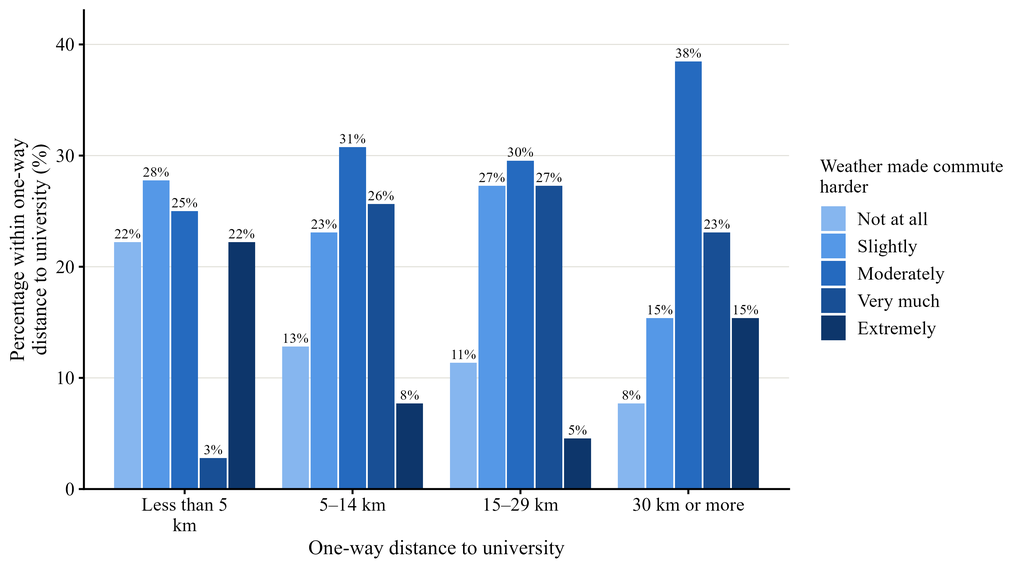

The effect of weather is broadly similar across distances. Weather made the commute very much or extremely harder for 25.0% of students living less than 5 km away, 33.3% at 5–14 km, 31.8% at 15–29 km and 38.5% at 30 km or more. Students living nearby are the most likely to say the weather had no effect (22.2%), but 22.2% of them also found it extremely hard, probably because many of them walk or cycle.

### 1.2.3 Main transport mode compared with other variables

#### Mode from home to main vehicle by main transport mode

|  | Main transport mode | Walk | Direct access | Dropped by someone | Three-wheeler | Bus | Total |
| --- | --- | --- | --- | --- | --- | --- | --- |
| Bus | Bus | 52 (71.2%) | 1 (1.4%) | 9 (12.3%) | 8 (11.0%) | 3 (4.1%) | 73 (100%) |
| Private vehicle | Private vehicle | 4 (14.8%) | 20 (74.1%) | 3 (11.1%) | 0 (0.0%) | 0 (0.0%) | 27 (100%) |
| Walk or bicycle | Walk or bicycle | 0 (0.0%) | 18 (100.0%) | 0 (0.0%) | 0 (0.0%) | 0 (0.0%) | 18 (100%) |
| Three-wheeler / taxi | Three-wheeler / taxi | 1 (12.5%) | 5 (62.5%) | 0 (0.0%) | 2 (25.0%) | 0 (0.0%) | 8 (100%) |
| Train | Train | 2 (33.3%) | 0 (0.0%) | 2 (33.3%) | 0 (0.0%) | 2 (33.3%) | 6 (100%) |
| 6 | Total | 59 (44.7%) | 44 (33.3%) | 14 (10.6%) | 10 (7.6%) | 5 (3.8%) | 132 (100%) |

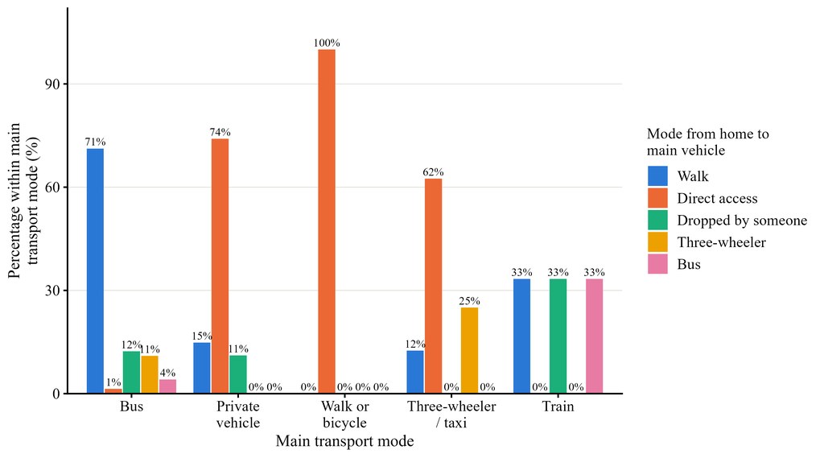

How students reach their main vehicle depends on the mode. Most bus users (71.2%) walk to the bus, while most private-vehicle users (74.1%) and all students who walk or cycle (100.0%) have direct access. Three-wheeler or taxi users also mostly have direct access (62.5%), whereas train users walk, are dropped off or take a bus to the station (33.3% each).

#### Mode from main vehicle to university gate by main transport mode

|  | Main transport mode | Walk | Direct drop-off | Three-wheeler | Bus | Total |
| --- | --- | --- | --- | --- | --- | --- |
| Bus | Bus | 52 (71.2%) | 2 (2.7%) | 17 (23.3%) | 2 (2.7%) | 73 (100%) |
| Private vehicle | Private vehicle | 7 (25.9%) | 19 (70.4%) | 1 (3.7%) | 0 (0.0%) | 27 (100%) |
| Walk or bicycle | Walk or bicycle | 0 (0.0%) | 18 (100.0%) | 0 (0.0%) | 0 (0.0%) | 18 (100%) |
| Three-wheeler / taxi | Three-wheeler / taxi | 2 (25.0%) | 5 (62.5%) | 1 (12.5%) | 0 (0.0%) | 8 (100%) |
| Train | Train | 3 (50.0%) | 0 (0.0%) | 3 (50.0%) | 0 (0.0%) | 6 (100%) |
| 6 | Total | 64 (48.5%) | 44 (33.3%) | 22 (16.7%) | 2 (1.5%) | 132 (100%) |

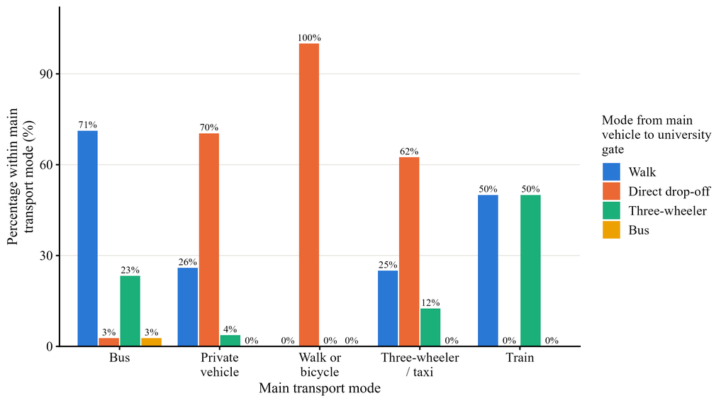

For the last stretch to the university gate, most bus users walk (71.2%) and 23.3% take a three-wheeler. Most private-vehicle users (70.4%) and all students who walk or cycle reach the gate directly. Train users either walk (50.0%) or take a three-wheeler (50.0%) from the station. Public-transport users therefore usually need an extra leg at the end of their journey.

#### Seat availability by main transport mode

|  | Main transport mode | Get a seat | Not applicable | Stand | Total |
| --- | --- | --- | --- | --- | --- |
| Bus | Bus | 43 (58.9%) | 1 (1.4%) | 29 (39.7%) | 73 (100%) |
| Private vehicle | Private vehicle | 12 (44.4%) | 15 (55.6%) | 0 (0.0%) | 27 (100%) |
| Walk or bicycle | Walk or bicycle | 0 (0.0%) | 18 (100.0%) | 0 (0.0%) | 18 (100%) |
| Three-wheeler / taxi | Three-wheeler / taxi | 5 (62.5%) | 3 (37.5%) | 0 (0.0%) | 8 (100%) |
| Train | Train | 1 (16.7%) | 1 (16.7%) | 4 (66.7%) | 6 (100%) |
| 6 | Total | 61 (46.2%) | 38 (28.8%) | 33 (25.0%) | 132 (100%) |

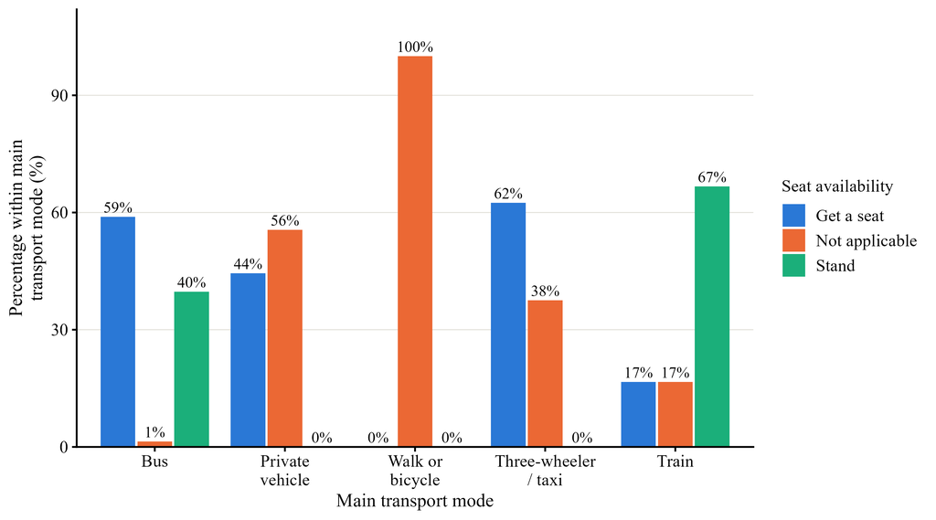

Among bus users, 58.9% usually get a seat but 39.7% usually stand. Train users stand even more often (66.7%), although this group is small (n = 6). Private-vehicle and three-wheeler users either get a seat or found the question not applicable, and the question does not apply to students who walk or cycle.

#### Late arrivals (15+ minutes) by main transport mode

|  | Main transport mode | Never | 1 day/week | 2+ days/week | Total |
| --- | --- | --- | --- | --- | --- |
| Bus | Bus | 23 (31.5%) | 27 (37.0%) | 23 (31.5%) | 73 (100%) |
| Private vehicle | Private vehicle | 11 (40.7%) | 9 (33.3%) | 7 (25.9%) | 27 (100%) |
| Walk or bicycle | Walk or bicycle | 6 (33.3%) | 4 (22.2%) | 8 (44.4%) | 18 (100%) |
| Three-wheeler / taxi | Three-wheeler / taxi | 5 (62.5%) | 3 (37.5%) | 0 (0.0%) | 8 (100%) |
| Train | Train | 2 (33.3%) | 2 (33.3%) | 2 (33.3%) | 6 (100%) |
| 6 | Total | 47 (35.6%) | 45 (34.1%) | 40 (30.3%) | 132 (100%) |

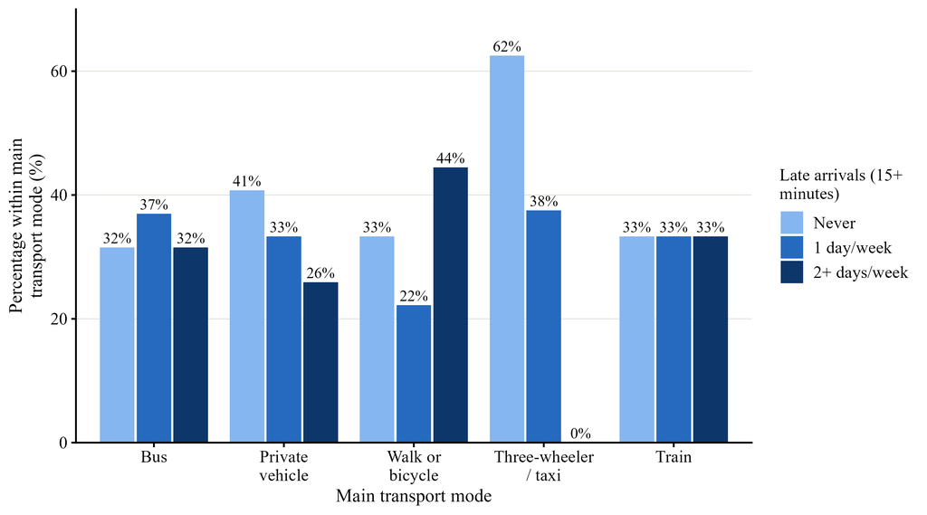

Late arrivals occur with every mode. About one-third of bus users (31.5%) and train users (33.3%) are late two or more days a week, and the share is highest among students who walk or cycle (44.4%). Three-wheeler or taxi users are the most punctual: 62.5% are never late and none are late two or more days a week.

#### One-way trip time by main transport mode

|  | Main transport mode | Under 30 min | 30–59 min | 1 to 1½ hours | 1½ to 2 hours | Over 2 hours | Total |
| --- | --- | --- | --- | --- | --- | --- | --- |
| Bus | Bus | 8 (11.0%) | 20 (27.4%) | 21 (28.8%) | 18 (24.7%) | 6 (8.2%) | 73 (100%) |
| Private vehicle | Private vehicle | 13 (48.1%) | 12 (44.4%) | 1 (3.7%) | 1 (3.7%) | 0 (0.0%) | 27 (100%) |
| Walk or bicycle | Walk or bicycle | 18 (100.0%) | 0 (0.0%) | 0 (0.0%) | 0 (0.0%) | 0 (0.0%) | 18 (100%) |
| Three-wheeler / taxi | Three-wheeler / taxi | 5 (62.5%) | 2 (25.0%) | 0 (0.0%) | 1 (12.5%) | 0 (0.0%) | 8 (100%) |
| Train | Train | 0 (0.0%) | 1 (16.7%) | 2 (33.3%) | 3 (50.0%) | 0 (0.0%) | 6 (100%) |
| 6 | Total | 44 (33.3%) | 35 (26.5%) | 24 (18.2%) | 23 (17.4%) | 6 (4.5%) | 132 (100%) |

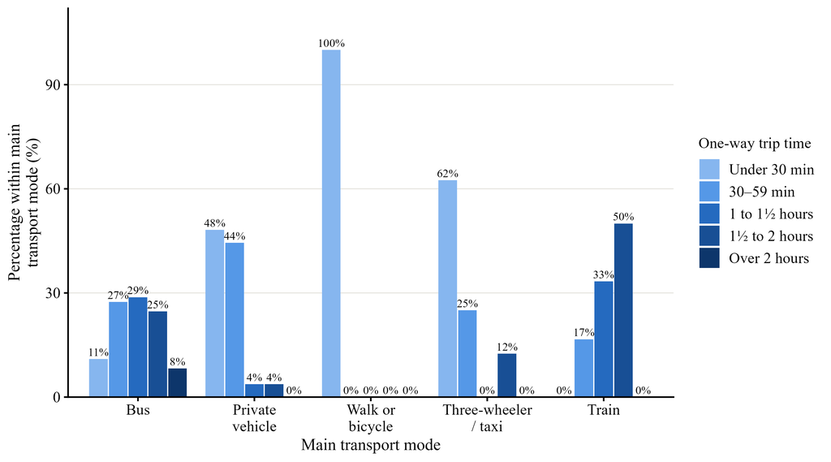

Trip time differs strongly by mode. All students who walk or cycle arrive in under 30 minutes, and 92.6% of private-vehicle users take less than an hour. In contrast, 61.6% of bus users and 83.3% of train users travel for an hour or more each way, and 8.2% of bus users travel for over 2 hours.

#### Waiting time for vehicle by main transport mode

|  | Main transport mode | I don’t wait | Under 5 min | 5–15 min | 15 min or more | Total |
| --- | --- | --- | --- | --- | --- | --- |
| Bus | Bus | 3 (4.1%) | 17 (23.3%) | 39 (53.4%) | 14 (19.2%) | 73 (100%) |
| Private vehicle | Private vehicle | 22 (81.5%) | 3 (11.1%) | 1 (3.7%) | 1 (3.7%) | 27 (100%) |
| Walk or bicycle | Walk or bicycle | 18 (100.0%) | 0 (0.0%) | 0 (0.0%) | 0 (0.0%) | 18 (100%) |
| Three-wheeler / taxi | Three-wheeler / taxi | 0 (0.0%) | 4 (50.0%) | 3 (37.5%) | 1 (12.5%) | 8 (100%) |
| Train | Train | 0 (0.0%) | 1 (16.7%) | 5 (83.3%) | 0 (0.0%) | 6 (100%) |
| 6 | Total | 43 (32.6%) | 25 (18.9%) | 48 (36.4%) | 16 (12.1%) | 132 (100%) |

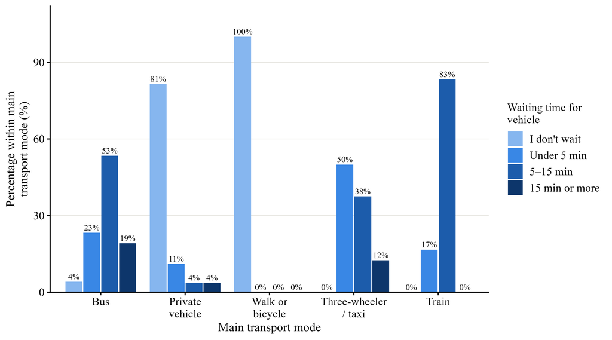

Waiting is mainly a public-transport issue. Most private-vehicle users (81.5%) and all students who walk or cycle do not wait. More than half of bus users (53.4%) wait 5–15 minutes and 19.2% wait 15 minutes or more, while 83.3% of train users wait 5–15 minutes.

#### Departure time by main transport mode

|  | Main transport mode | Before 6:00 am | 6:00–6:59 am | 7:00–7:59 am | 8:00 am or later | Total |
| --- | --- | --- | --- | --- | --- | --- |
| Bus | Bus | 10 (13.7%) | 37 (50.7%) | 21 (28.8%) | 5 (6.8%) | 73 (100%) |
| Private vehicle | Private vehicle | 2 (7.4%) | 8 (29.6%) | 13 (48.1%) | 4 (14.8%) | 27 (100%) |
| Walk or bicycle | Walk or bicycle | 0 (0.0%) | 0 (0.0%) | 13 (72.2%) | 5 (27.8%) | 18 (100%) |
| Three-wheeler / taxi | Three-wheeler / taxi | 1 (12.5%) | 2 (25.0%) | 5 (62.5%) | 0 (0.0%) | 8 (100%) |
| Train | Train | 2 (33.3%) | 4 (66.7%) | 0 (0.0%) | 0 (0.0%) | 6 (100%) |
| 6 | Total | 15 (11.4%) | 51 (38.6%) | 52 (39.4%) | 14 (10.6%) | 132 (100%) |

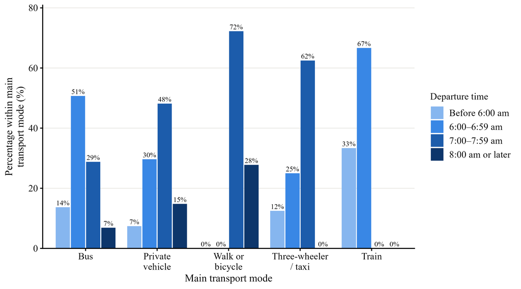

Bus and train users leave home earliest: 64.4% of bus users and all train users leave before 7:00 am. Private-vehicle users most often leave between 7:00 and 7:59 am (48.1%), and all students who walk or cycle leave at 7:00 am or later.

#### How often students feel unsafe by main transport mode

|  | Main transport mode | Never | Rarely | Sometimes | Often | Total |
| --- | --- | --- | --- | --- | --- | --- |
| Bus | Bus | 12 (16.4%) | 30 (41.1%) | 25 (34.2%) | 6 (8.2%) | 73 (100%) |
| Private vehicle | Private vehicle | 10 (37.0%) | 8 (29.6%) | 7 (25.9%) | 2 (7.4%) | 27 (100%) |
| Walk or bicycle | Walk or bicycle | 12 (66.7%) | 5 (27.8%) | 0 (0.0%) | 1 (5.6%) | 18 (100%) |
| Three-wheeler / taxi | Three-wheeler / taxi | 2 (25.0%) | 3 (37.5%) | 3 (37.5%) | 0 (0.0%) | 8 (100%) |
| Train | Train | 0 (0.0%) | 1 (16.7%) | 5 (83.3%) | 0 (0.0%) | 6 (100%) |
| 6 | Total | 36 (27.3%) | 47 (35.6%) | 40 (30.3%) | 9 (6.8%) | 132 (100%) |

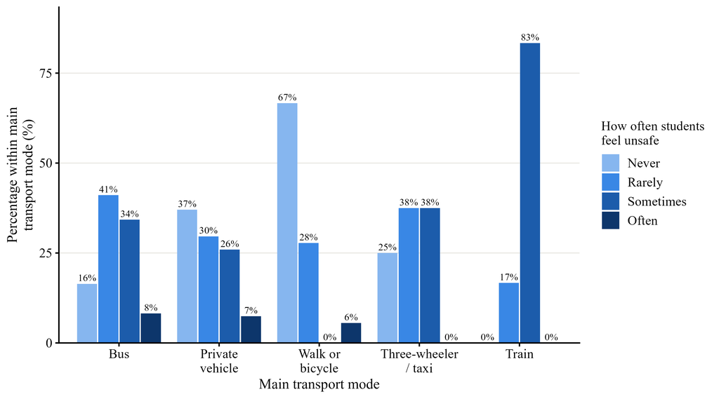

Feeling unsafe is more common on public transport. Among train users, 83.3% sometimes feel unsafe, and 42.4% of bus users feel unsafe sometimes or often. In contrast, 66.7% of students who walk or cycle and 37.0% of private-vehicle users never feel unsafe.

#### Crowding on bus/train by main transport mode

|  | Main transport mode | Not/slightly crowded | Moderately crowded | Very crowded | Extremely crowded | Total |
| --- | --- | --- | --- | --- | --- | --- |
| Bus | Bus | 20 (27.4%) | 24 (32.9%) | 24 (32.9%) | 5 (6.8%) | 73 (100%) |
| Train | Train | 0 (0.0%) | 0 (0.0%) | 6 (100.0%) | 0 (0.0%) | 6 (100%) |
| 3 | Total | 20 (25.3%) | 24 (30.4%) | 30 (38.0%) | 5 (6.3%) | 79 (100%) |

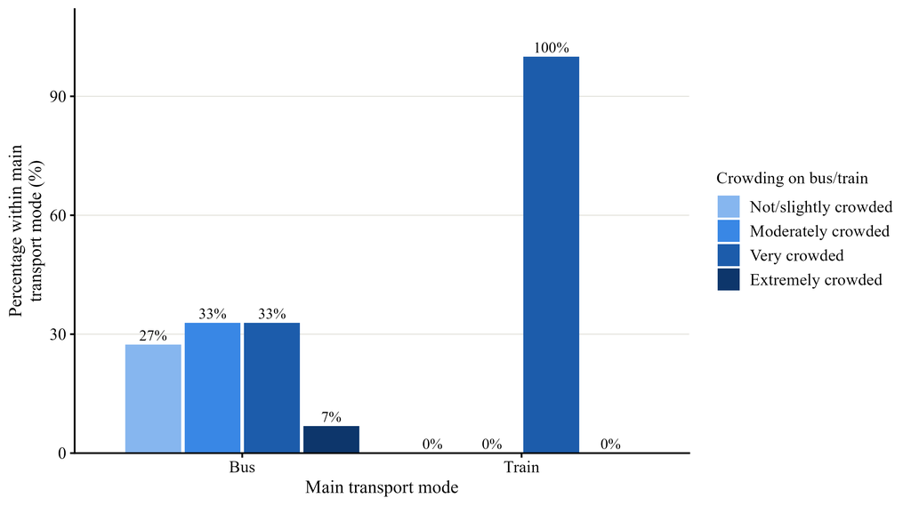

Only bus and train users answered this question. All six train users described their train as very crowded. Bus users reported a wider range: 39.7% found the bus very or extremely crowded, 32.9% moderately crowded and 27.4% not or slightly crowded.

#### Weather made commute harder by main transport mode

|  | Main transport mode | Not at all | Slightly | Moderately | Very much | Extremely | Total |
| --- | --- | --- | --- | --- | --- | --- | --- |
| Bus | Bus | 8 (11.0%) | 17 (23.3%) | 21 (28.8%) | 19 (26.0%) | 8 (11.0%) | 73 (100%) |
| Private vehicle | Private vehicle | 2 (7.4%) | 7 (25.9%) | 11 (40.7%) | 4 (14.8%) | 3 (11.1%) | 27 (100%) |
| Walk or bicycle | Walk or bicycle | 6 (33.3%) | 5 (27.8%) | 3 (16.7%) | 1 (5.6%) | 3 (16.7%) | 18 (100%) |
| Three-wheeler / taxi | Three-wheeler / taxi | 1 (12.5%) | 2 (25.0%) | 3 (37.5%) | 1 (12.5%) | 1 (12.5%) | 8 (100%) |
| Train | Train | 2 (33.3%) | 2 (33.3%) | 1 (16.7%) | 1 (16.7%) | 0 (0.0%) | 6 (100%) |
| 6 | Total | 19 (14.4%) | 33 (25.0%) | 39 (29.5%) | 26 (19.7%) | 15 (11.4%) | 132 (100%) |

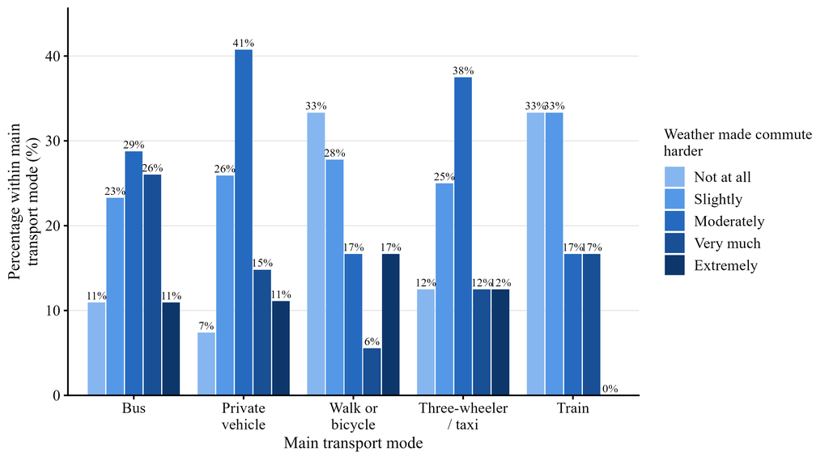

Weather affects bus users the most: 37.0% of them said it made the commute very much or extremely harder. The share is lower for private-vehicle users (25.9%) and for those who walk or cycle (22.2%), and one-third (33.3%) of students who walk or cycle said the weather had no effect at all.

### 1.2.4 Residence compared with other variables

#### Stress level by residence during semester

|  | Residence during semester | Low | Moderate | High | Total |
| --- | --- | --- | --- | --- | --- |
| Home | Home | 9 (8.7%) | 65 (63.1%) | 29 (28.2%) | 103 (100%) |
| Boarding place | Boarding place | 1 (5.0%) | 17 (85.0%) | 2 (10.0%) | 20 (100%) |
| University hostel | University hostel | 4 (50.0%) | 3 (37.5%) | 1 (12.5%) | 8 (100%) |
| Other (please specify) | Other (please specify) | 1 (100.0%) | 0 (0.0%) | 0 (0.0%) | 1 (100%) |
| 5 | Total | 15 (11.4%) | 85 (64.4%) | 32 (24.2%) | 132 (100%) |

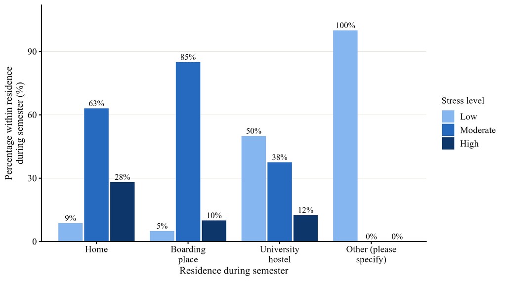

#### Main transport mode by residence during semester

|  | Residence during semester | Bus | Private vehicle | Walk or bicycle | Three-wheeler / taxi | Train | Total |
| --- | --- | --- | --- | --- | --- | --- | --- |
| Home | Home | 67 (65.0%) | 24 (23.3%) | 0 (0.0%) | 6 (5.8%) | 6 (5.8%) | 103 (100%) |
| Boarding place | Boarding place | 5 (25.0%) | 1 (5.0%) | 14 (70.0%) | 0 (0.0%) | 0 (0.0%) | 20 (100%) |
| University hostel | University hostel | 1 (12.5%) | 2 (25.0%) | 4 (50.0%) | 1 (12.5%) | 0 (0.0%) | 8 (100%) |
| Other (please specify) | Other (please specify) | 0 (0.0%) | 0 (0.0%) | 0 (0.0%) | 1 (100.0%) | 0 (0.0%) | 1 (100%) |
| 5 | Total | 73 (55.3%) | 27 (20.5%) | 18 (13.6%) | 8 (6.1%) | 6 (4.5%) | 132 (100%) |

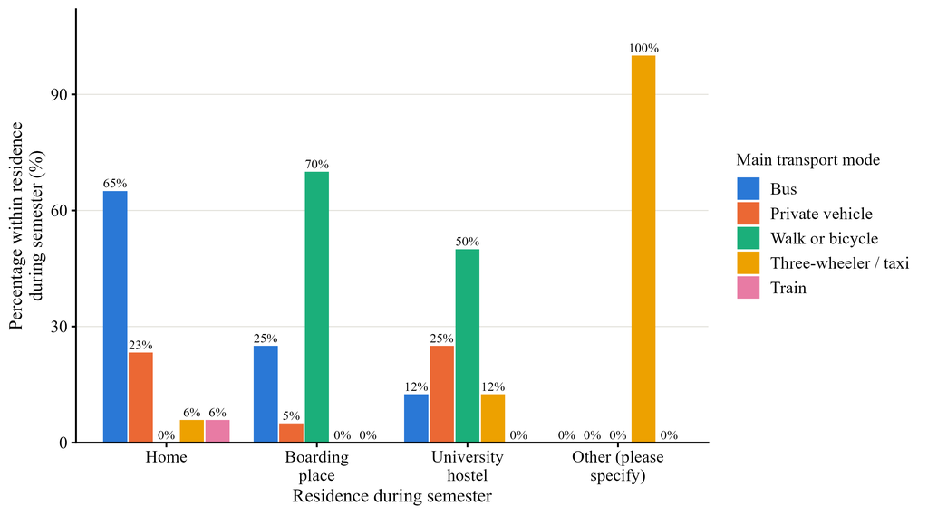

#### One-way distance to university by residence during semester

|  | Residence during semester | Less than 5 km | 5–14 km | 15–29 km | 30 km or more | Total |
| --- | --- | --- | --- | --- | --- | --- |
| Home | Home | 12 (11.7%) | 36 (35.0%) | 42 (40.8%) | 13 (12.6%) | 103 (100%) |
| Boarding place | Boarding place | 18 (90.0%) | 2 (10.0%) | 0 (0.0%) | 0 (0.0%) | 20 (100%) |
| University hostel | University hostel | 5 (62.5%) | 1 (12.5%) | 2 (25.0%) | 0 (0.0%) | 8 (100%) |
| Other (please specify) | Other (please specify) | 1 (100.0%) | 0 (0.0%) | 0 (0.0%) | 0 (0.0%) | 1 (100%) |
| 5 | Total | 36 (27.3%) | 39 (29.5%) | 44 (33.3%) | 13 (9.8%) | 132 (100%) |

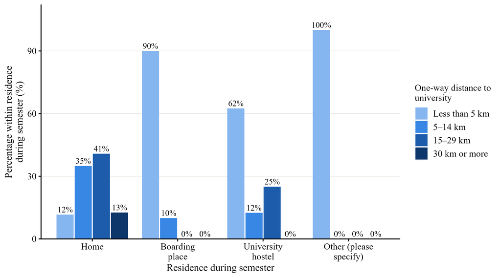

## 1.3 Three qualitative variables

Trip time is grouped into three classes and main mode into two (see the `merged-data` chunk) so that each group still has enough students.

### Stress level by trip time and gender

|  | Gender | One-way trip time | Low | Moderate | High | Total |
| --- | --- | --- | --- | --- | --- | --- |
| Under 30 min | Male | Under 30 min | 10 (38.5%) | 15 (57.7%) | 1 (3.8%) | 26 (100%) |
| 30–59 min |  | 30–59 min | 2 (11.1%) | 15 (83.3%) | 1 (5.6%) | 18 (100%) |
| 1 hour or more |  | 1 hour or more | 0 (0.0%) | 16 (59.3%) | 11 (40.7%) | 27 (100%) |
| 4 |  | Total | 12 (16.9%) | 46 (64.8%) | 13 (18.3%) | 71 (100%) |
| Under 30 min1 | Female | Under 30 min | 3 (16.7%) | 13 (72.2%) | 2 (11.1%) | 18 (100%) |
| 30–59 min1 |  | 30–59 min | 0 (0.0%) | 11 (64.7%) | 6 (35.3%) | 17 (100%) |
| 1 hour or more1 |  | 1 hour or more | 0 (0.0%) | 15 (57.7%) | 11 (42.3%) | 26 (100%) |
| 41 |  | Total | 3 (4.9%) | 39 (63.9%) | 19 (31.1%) | 61 (100%) |

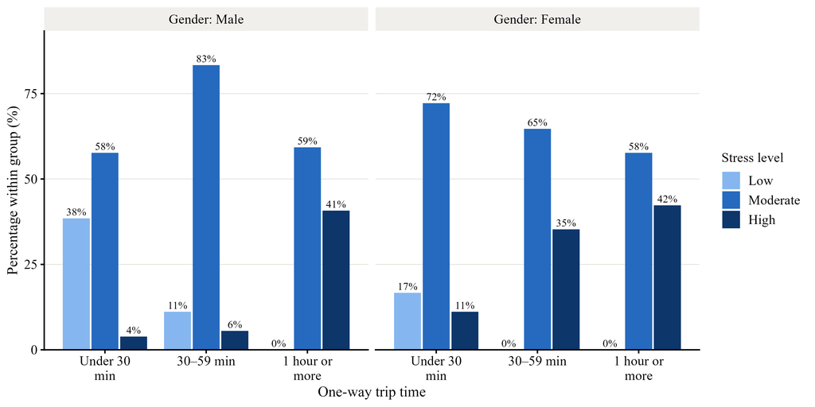

When trip time is taken into account, the gender difference appears mainly for shorter trips. For trips under one hour, female students are more often highly stressed than male students (11.1% vs 3.8% for under 30 minutes, and 35.3% vs 5.6% for 30–59 minutes). For trips of one hour or more, the share of highly stressed students is almost the same for both genders (40.7% for males and 42.3% for females). Long trips are therefore stressful regardless of gender.

### Stress level by trip time and seat availability (bus and train users)

Only bus and train users who usually get a seat or usually stand are included.

|  | Seat availability | One-way trip time | Low | Moderate | High | Total |
| --- | --- | --- | --- | --- | --- | --- |
| Under 30 min | Get a seat | Under 30 min | 1 (25.0%) | 3 (75.0%) | 0 (0.0%) | 4 (100%) |
| 30–59 min |  | 30–59 min | 0 (0.0%) | 7 (87.5%) | 1 (12.5%) | 8 (100%) |
| 1 hour or more |  | 1 hour or more | 0 (0.0%) | 18 (56.2%) | 14 (43.8%) | 32 (100%) |
| 4 |  | Total | 1 (2.3%) | 28 (63.6%) | 15 (34.1%) | 44 (100%) |
| Under 30 min1 | Stand | Under 30 min | 0 (0.0%) | 3 (75.0%) | 1 (25.0%) | 4 (100%) |
| 30–59 min1 |  | 30–59 min | 0 (0.0%) | 9 (75.0%) | 3 (25.0%) | 12 (100%) |
| 1 hour or more1 |  | 1 hour or more | 0 (0.0%) | 10 (58.8%) | 7 (41.2%) | 17 (100%) |
| 41 |  | Total | 0 (0.0%) | 22 (66.7%) | 11 (33.3%) | 33 (100%) |

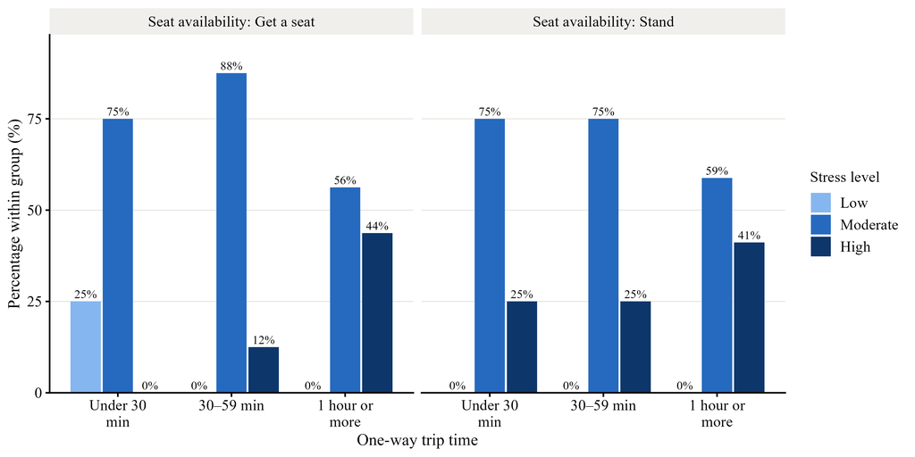

Among bus and train users, the share of highly stressed students rises with trip time both for those who get a seat and for those who stand. For trips of one hour or more, 43.8% of students who usually get a seat are highly stressed, which is similar to the 41.2% of those who usually stand. Trip duration therefore matters more than having a seat. The groups with trips under one hour are small (4–12 students), so their percentages should be treated with caution.

### Stress level by distance and main transport mode

|  | Main transport mode | One-way distance to university | Low | Moderate | High | Total |
| --- | --- | --- | --- | --- | --- | --- |
| Under 15 km | Bus / train | Under 15 km | 1 (2.9%) | 24 (68.6%) | 10 (28.6%) | 35 (100%) |
| 15 km or more |  | 15 km or more | 0 (0.0%) | 27 (61.4%) | 17 (38.6%) | 44 (100%) |
| 3 |  | Total | 1 (1.3%) | 51 (64.6%) | 27 (34.2%) | 79 (100%) |
| Under 15 km1 | Private / hired | Under 15 km | 9 (40.9%) | 12 (54.5%) | 1 (4.5%) | 22 (100%) |
| 15 km or more1 |  | 15 km or more | 2 (15.4%) | 8 (61.5%) | 3 (23.1%) | 13 (100%) |
| 31 |  | Total | 11 (31.4%) | 20 (57.1%) | 4 (11.4%) | 35 (100%) |
| Under 15 km2 | Walk / bicycle | Under 15 km | 3 (16.7%) | 14 (77.8%) | 1 (5.6%) | 18 (100%) |
| 2 |  | Total | 3 (16.7%) | 14 (77.8%) | 1 (5.6%) | 18 (100%) |

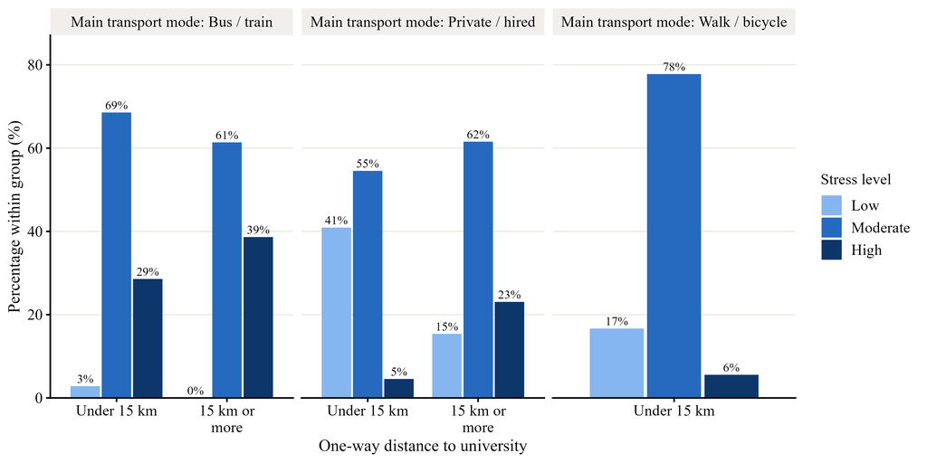

Within each mode group, stress is higher for longer distances. Among bus and train users, high stress rises from 28.6% (under 15 km) to 38.6% (15 km or more). Among private or hired vehicle users, it rises from 4.5% to 23.1%, while low stress falls from 40.9% to 15.4%. At both distances, public-transport users are more often highly stressed than private or hired vehicle users, so both mode and distance are related to stress. All students who walk or cycle live under 15 km away, and only 5.6% of them are highly stressed.

# 2. Data description

## 2.1 One quantitative variable: stress score

### Summary measures and skewness

The score is recalculated from C1–C3 without rounding, so quartiles and outlier fences are exact. Quartiles use the same method as Minitab (`type = 6`). Skewness is the adjusted Fisher–Pearson coefficient (as in Minitab and Excel `SKEW`):

- between −0.5 and +0.5: approximately symmetric → use **mean, SD and variance**
- below −0.5: negatively skewed; above +0.5: positively skewed → use **median and IQR**

| Measure | Value |
| --- | --- |
| n | 132.000 |
| Minimum | -3.000 |
| Q1 | -0.333 |
| Median (Q2) | 0.333 |
| Q3 | 1.000 |
| Maximum | 3.000 |
| Skewness | -0.575 |

Skewness = **-0.575**, so the stress score distribution is **negatively skewed**.

|  | Measure | Value |
| --- | --- | --- |
| 50% | Median | 0.333 |
|  | Interquartile range (IQR = Q3 − Q1) | 1.333 |

The stress score ranges from −3.00 to +3.00, with a median of 0.33, meaning that the typical student feels slightly more stressed than relaxed during the commute. The middle 50% of students have scores between −0.33 (Q1) and 1.00 (Q3), giving an interquartile range of 1.33. The skewness coefficient is −0.575, so the distribution is moderately negatively skewed; the median and IQR are therefore used instead of the mean and standard deviation.

### Histogram

Each bar is one possible score (scores move in steps of 1/3). Bar colours show the stress level; the dashed lines mark the cut-offs at −1 and +1.

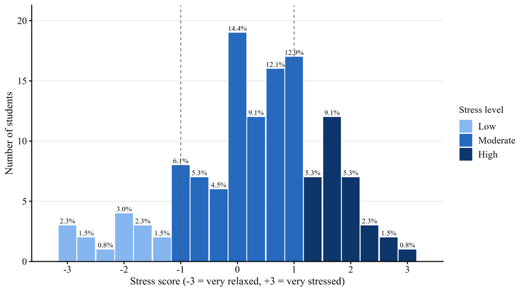

The most common score is 0.00 (19 students), followed by 1.00 (17) and 0.67 (16), and 64.39% of the scores fall between −1 and +1 (moderate stress). The distribution has a longer tail to the left, towards the relaxed end, which confirms the negative skewness. More students fall above +1 (high stress, 24.24%) than below −1 (low stress, 11.36%).

### Box plot

The box runs from Q1 to Q3 with the median (Q2) inside. The whiskers reach the smallest and largest scores that are **not** outliers. Outliers are scores more than 1.5 × IQR below Q1 or above Q3.

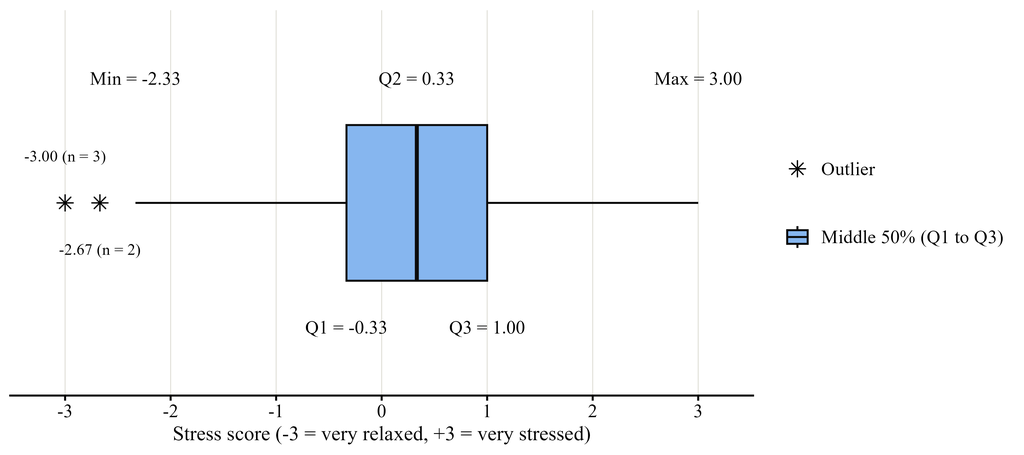

| Outlier score | Number of students |
| --- | --- |
| -3.00 | 3 |
| -2.67 | 2 |

Lower fence = -2.33, upper fence = 3.

The box is centred on the median (0.33), and both whiskers have the same length (2.00 units, from −2.33 to −0.33 and from 1.00 to 3.00). The negative skewness therefore comes mainly from five low outliers: three students scored −3.00 and two scored −2.67, meaning they felt very relaxed, confident and calm. These are genuine responses rather than errors, so they are kept in the analysis. A score of −2.33 lies exactly on the lower fence and is therefore not treated as an outlier, and there are no high outliers.

# 3. Relationships between variables

A Pearson correlation matrix only measures **straight-line relationships between numeric variables**, so it is not suitable here. This section uses measures made for categorical data:

- **Spearman’s rho** (3.1): for ordinal variables and the stress score. It measures any relationship that keeps going in one direction (as one goes up, the other tends to go up, or down). It runs from −1 to +1.
- **Cramér’s V** (3.2, 3.3): for any two categorical variables, nominal or ordinal. It is based on the chi-square test and runs from 0 (no association) to 1 (perfect association). It has no sign, so it shows strength only. The bias-corrected version is used, because the ordinary version is too high in small samples with many categories. Merged categories (`data_m`) are used.

Rough guide to strength (both measures): below 0.10 negligible, 0.10–0.29 weak, 0.30–0.49 moderate, 0.50 or above strong.

## 3.1 Spearman correlation: ordinal variables and stress score

Each ordinal variable is turned into its rank order (1, 2, 3, …). Blue means a positive relationship and orange a negative one; * marks p < 0.05. C1–C3 and stress level are left out because the stress score is built from them.

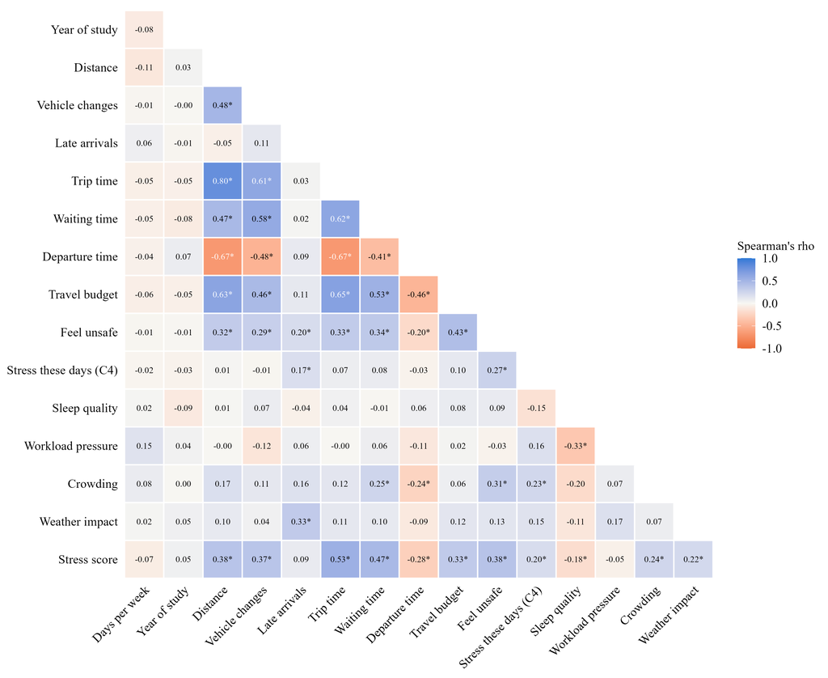

| Variable | Spearman’s rho with stress score | p-value |
| --- | --- | --- |
| Trip time | 0.531 | 0.00e+00 |
| Waiting time | 0.466 | 0.00e+00 |
| Feel unsafe | 0.381 | 6.40e-06 |
| Distance | 0.376 | 8.90e-06 |
| Vehicle changes | 0.371 | 1.18e-05 |
| Travel budget | 0.330 | 1.10e-04 |
| Departure time | -0.275 | 1.41e-03 |
| Crowding | 0.236 | 3.61e-02 |
| Weather impact | 0.219 | 1.17e-02 |
| Stress these days (C4) | 0.196 | 2.40e-02 |
| Sleep quality | -0.176 | 4.36e-02 |
| Late arrivals | 0.088 | 3.18e-01 |
| Days per week | -0.068 | 4.41e-01 |
| Year of study | 0.047 | 5.95e-01 |
| Workload pressure | -0.046 | 6.03e-01 |

Several travel variables have moderate positive correlations with the stress score: trip time (ρ = 0.53), waiting time (0.47), feeling unsafe (0.38), distance (0.38), vehicle changes (0.37) and travel budget (0.33), all with p < 0.001. Departure time is negatively correlated with stress (ρ = −0.28, p = 0.001), so students who leave later are less stressed. Crowding (0.24), weather impact (0.22), general stress (C4, 0.20) and sleep quality (−0.18) have weak but significant correlations, while late arrivals, days per week, year of study and workload pressure are not significantly related to the stress score. The travel variables are also strongly correlated with one another, especially distance and trip time (ρ = 0.80), so their relationships with stress overlap.

## 3.2 Cramér’s V: all categorical variables

- marks a significant chi-square test (p < 0.05, Monte Carlo p-value). Darker cells mean a stronger association.

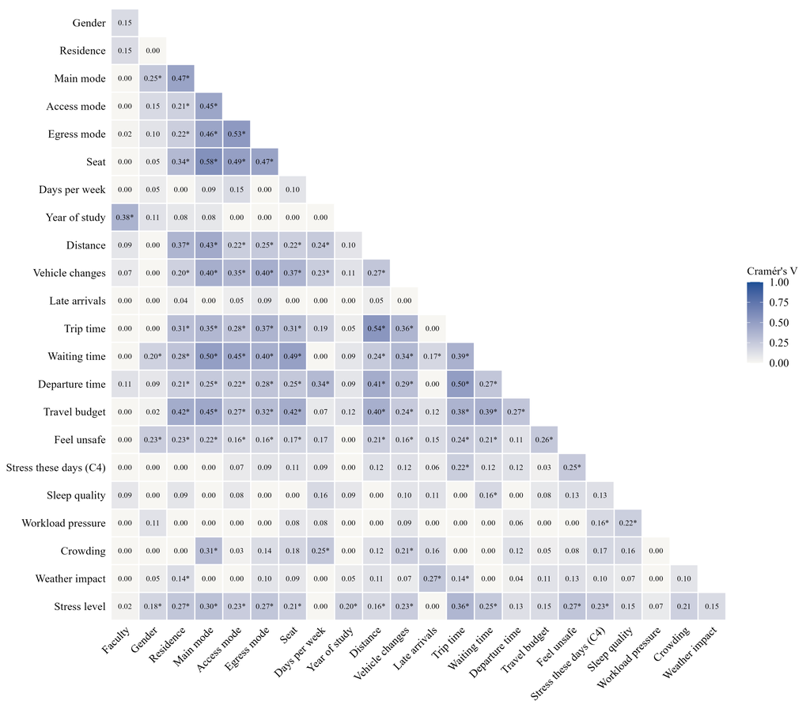

Ten strongest associations between variables

| Variable 1 | Variable 2 | Cramér’s V | p-value |
| --- | --- | --- | --- |
| Main mode | Seat | 0.576 | 2e-04 |
| Distance | Trip time | 0.544 | 2e-04 |
| Access mode | Egress mode | 0.526 | 2e-04 |
| Trip time | Departure time | 0.503 | 2e-04 |
| Main mode | Waiting time | 0.498 | 2e-04 |
| Access mode | Seat | 0.490 | 2e-04 |
| Seat | Waiting time | 0.486 | 2e-04 |
| Residence | Main mode | 0.471 | 2e-04 |
| Egress mode | Seat | 0.471 | 2e-04 |
| Main mode | Egress mode | 0.458 | 2e-04 |

## 3.3 Which variables are most associated with stress level?

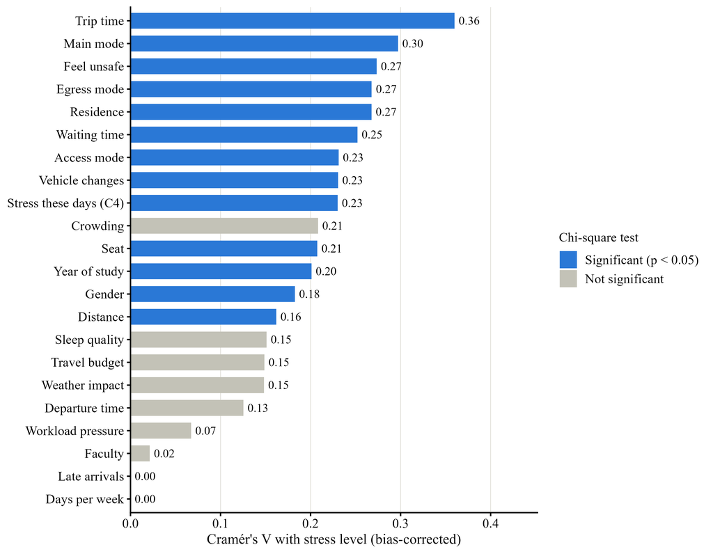

| Variable | Cramér’s V with stress level | p-value |
| --- | --- | --- |
| Trip time | 0.360 | 0.0002 |
| Main mode | 0.297 | 0.0008 |
| Feel unsafe | 0.273 | 0.0002 |
| Egress mode | 0.268 | 0.0010 |
| Residence | 0.268 | 0.0012 |
| Waiting time | 0.252 | 0.0018 |
| Access mode | 0.231 | 0.0070 |
| Vehicle changes | 0.231 | 0.0040 |
| Stress these days (C4) | 0.230 | 0.0070 |
| Crowding | 0.208 | 0.0788 |
| Seat | 0.207 | 0.0034 |
| Year of study | 0.201 | 0.0202 |
| Gender | 0.183 | 0.0424 |
| Distance | 0.162 | 0.0440 |
| Sleep quality | 0.151 | 0.0828 |
| Travel budget | 0.149 | 0.0832 |
| Weather impact | 0.148 | 0.0848 |
| Departure time | 0.125 | 0.1180 |
| Workload pressure | 0.067 | 0.2900 |
| Faculty | 0.021 | 0.4250 |
| Days per week | 0.000 | 0.6300 |
| Late arrivals | 0.000 | 0.5600 |

All tables are saved in **tables/analysis-tables.xlsx** (the *Index* sheet lists them) and all graphs are in the **figures** folder.